# Total_goals_in_likely_draw_matches

Kutálek Jiří

2024-02-09

```r
library(tidyr)
library(dplyr)
library(agricolae)
```

```r
library(ggplot2)
library(base)
```

### Read data

```r
src_filename = "matches_10_10.csv"

dat_raw <- read.csv2(file = paste0("C:\\Users\\kutalekj\\PycharmProjects\\MyFlashscoreScraper\\src\\", src_filename), header = TRUE, sep = ",")
```

### Adjust data

- convert to `factors`
- convert `floats` (**Expected Goals** and **Odds**) to `numerics`
- convert other numerical values to `integers`
- convert date & time to `datetime`
- replace conflicting `:` symbol with `_`
- add attribute for **total goals** in match

```r
dat <- dat_raw |> mutate(
  across(
    c(team_home, team_away, country, competition, season, referee, neutral_field, finished, no_spectators), factor))
dat <- dat |> mutate(
  across(
    where(is.character) & (starts_with("odd") | starts_with("expected")), as.numeric))
dat <- dat |> mutate(
  across(
    where(is.character) & !c(id, date_time), as.integer))

dat$date_time <- as.POSIXct(dat$date_time, format="%Y-%m-%d %H:%M", tz="UTC")
dat <- dat |> mutate(
  competition = gsub(":", "_", competition)
)

dat <- dat |> mutate(
  total_goals = goals_home + goals_away
)
```

### Add column for **match group** `(country, competition, season)`

```r
dat <- dat |> mutate(
    match_group = factor(paste0(country, "_", competition, "_", season)))
```

### Add columns for **margins**

- four columns in total - **start**/**end** (“long time before match start”/“right before amtch start”) and **Tipsport**/**Fortuna**
- `NA_real_` if zero or invalid odd values

```r
dat <- dat |> mutate(
  margin_tipsport_start = ifelse(
    is.na(odd_tipsport_1_start) | is.na(odd_tipsport_0_start) | is.na(odd_tipsport_2_start) |
      odd_tipsport_1_start <= 0   | odd_tipsport_0_start <= 0   | odd_tipsport_2_start <= 0,
    NA_real_,
    (1/odd_tipsport_1_start + 1/odd_tipsport_0_start + 1/odd_tipsport_2_start) - 1),
  margin_tipsport_end = ifelse(
    is.na(odd_tipsport_1_end) | is.na(odd_tipsport_0_end) | is.na(odd_tipsport_2_end) |
      odd_tipsport_1_end <= 0   | odd_tipsport_0_end <= 0   | odd_tipsport_2_end <= 0,
    NA_real_,
    (1/odd_tipsport_1_end + 1/odd_tipsport_0_end + 1/odd_tipsport_2_end) - 1),
  margin_fortuna_start = ifelse(
    is.na(odd_fortuna_1_start) | is.na(odd_fortuna_0_start) | is.na(odd_fortuna_2_start) |
      odd_fortuna_1_start <= 0   | odd_fortuna_0_start <= 0   | odd_fortuna_2_start <= 0,
    NA_real_,
    (1/odd_fortuna_1_start + 1/odd_fortuna_0_start + 1/odd_fortuna_2_start) - 1),
  margin_fortuna_end = ifelse(
    is.na(odd_fortuna_1_end) | is.na(odd_fortuna_0_end) | is.na(odd_fortuna_2_end) |
      odd_fortuna_1_end <= 0   | odd_fortuna_0_end <= 0   | odd_fortuna_2_end <= 0,
    NA_real_,
    (1/odd_fortuna_1_end + 1/odd_fortuna_0_end + 1/odd_fortuna_2_end) - 1)
)

# Print out average margin (start and end)
print(paste0("Average margin by Tipsport for win/draw/loose is: ",
             mean(dat$margin_tipsport_start, na.rm = TRUE), ", ",
             mean(dat$margin_tipsport_end, na.rm = TRUE)))
```

```
[1] "Average margin by Tipsport for win/draw/loose is: 0.080782455136668, 0.0649206582920542"
```

```r
print(paste0("Average margin by Fortuna for win/draw/loose is: ",
             mean(dat$margin_fortuna_start, na.rm = TRUE), ", ",
             mean(dat$margin_fortuna_end, na.rm = TRUE)))
```

```
[1] "Average margin by Fortuna for win/draw/loose is: 0.0794368022966026, 0.0620917111830412"
```

```r
last_N_columns = 4
random_rows <- sample(nrow(dat), 10) # randomly take 10 rows
dat[random_rows, c(1, (ncol(dat) - (last_N_columns-1)) : ncol(dat))]
```

```
                                            id margin_tipsport_start
21178  15.10.2022 18:00_Banska Bystrica_Zilina            0.08638625
54954 04.08.2018 16:00_Kilmarnock_St Johnstone            0.08712121
46474     14.08.2023 20:00_Sanliurfaspor_Altay            0.10489847
54134      02.10.2022 18:00_APOEL_AEL Limassol            0.08135293
29768         31.05.2020 18:00_Esbjerg_Aalborg            0.07924723
59354       20.09.2021 20:00_Anorthosis_Achnas            0.08126987
21865          17.07.2021 21:00_Goias_Londrina            0.08082370
1681      29.04.2023 20:30_Servette_St. Gallen            0.06286312
30653     18.07.2020 16:30_Hatayspor_Bursaspor            0.11157796
41326   14.09.2020 18:00_Akhisarspor_Tuzlaspor            0.11098645
      margin_tipsport_end margin_fortuna_start margin_fortuna_end
21178          0.06237719           0.06788331         0.06876457
54954          0.06392106           0.08535226         0.07435897
46474          0.10624882           0.09794073         0.09711857
54134          0.08122471           0.08827895         0.06323529
29768          0.06367836           0.07616741         0.06557292
59354          0.07922821           0.11137693         0.08111748
21865          0.08257010           0.10987754         0.10000923
1681           0.06058082           0.07530434         0.05190744
30653          0.10408346           0.08939568         0.08530058
41326          0.10257535           0.11151515         0.12413230
```

### Add columns for win/draw/lose **probabilities without margins** (only **end**, not **start**)

- `prob_without_margin = prob_with_margin - prob_with_margin * (margin / sum_of_odds)`
- (`sum_of_odds = 1 + margin`)
- **two possibilities** of how to distirbute the total margin

```r
# A. Distribute the total margin PROPORTIONALLY to the 1/0/2 odds

dat <- dat |> mutate(
  prb_nomarg_1_tips_end = (1/odd_tipsport_1_end) - (1/odd_tipsport_1_end) * (margin_tipsport_end / (1/odd_tipsport_1_end + 1/odd_tipsport_0_end + 1/odd_tipsport_2_end)),
  prb_nomarg_0_tips_end = (1/odd_tipsport_0_end) - (1/odd_tipsport_0_end) * (margin_tipsport_end / (1/odd_tipsport_1_end + 1/odd_tipsport_0_end + 1/odd_tipsport_2_end)),
  prb_nomarg_2_tips_end = (1/odd_tipsport_2_end) - (1/odd_tipsport_2_end) * (margin_tipsport_end / (1/odd_tipsport_1_end + 1/odd_tipsport_0_end + 1/odd_tipsport_2_end)),
  prb_nomarg_1_fort_end = (1/odd_fortuna_1_end) - (1/odd_fortuna_1_end) * (margin_fortuna_end / (1/odd_fortuna_1_end + 1/odd_fortuna_0_end + 1/odd_fortuna_2_end)),
  prb_nomarg_0_fort_end = (1/odd_fortuna_0_end) - (1/odd_fortuna_0_end) * (margin_fortuna_end / (1/odd_fortuna_1_end + 1/odd_fortuna_0_end + 1/odd_fortuna_2_end)),
  prb_nomarg_2_fort_end = (1/odd_fortuna_2_end) - (1/odd_fortuna_2_end) * (margin_fortuna_end / (1/odd_fortuna_1_end + 1/odd_fortuna_0_end + 1/odd_fortuna_2_end))
)

# B. Distribute the total margin EQUALLY between the 1/0/2 odds (one third to each)

# dat <- dat |> mutate(
#   prb_nomarg_1_tips_end = (1/odd_tipsport_1_end) - (margin_tipsport_end / 3),
#   prb_nomarg_0_tips_end = (1/odd_tipsport_0_end) - (margin_tipsport_end / 3),
#   prb_nomarg_2_tips_end = (1/odd_tipsport_2_end) - (margin_tipsport_end / 3),
#   prb_nomarg_1_fort_end = (1/odd_fortuna_1_end) - (margin_fortuna_end / 3),
#   prb_nomarg_0_fort_end = (1/odd_fortuna_0_end) - (margin_fortuna_end / 3),
#   prb_nomarg_2_fort_end = (1/odd_fortuna_2_end) - (margin_fortuna_end / 3)
# )

# Print out average probabilities without margins (end, not start)
print(paste0("Average probabilities without margins by Tipsport for win/draw/loose are: ",
             mean(dat$prb_nomarg_1_tips_end, na.rm = TRUE), ", ",
             mean(dat$prb_nomarg_0_tips_end, na.rm = TRUE), ", ",
             mean(dat$prb_nomarg_2_tips_end, na.rm = TRUE)))
```

```
[1] "Average probabilities without margins by Tipsport for win/draw/loose are: 0.430217981048731, 0.266049613915006, 0.303732405036263"
```

```r
print(paste0("Average probabilities without margins by Fortuna for win/draw/loose are: ",
             mean(dat$prb_nomarg_1_fort_end, na.rm = TRUE), ", ",
             mean(dat$prb_nomarg_0_fort_end, na.rm = TRUE), ", ",
             mean(dat$prb_nomarg_2_fort_end, na.rm = TRUE)))
```

```
[1] "Average probabilities without margins by Fortuna for win/draw/loose are: 0.430964072399408, 0.263846488056595, 0.305189439543997"
```

```r
last_N_columns = 6
random_rows <- sample(nrow(dat), 10) # randomly take 10 rows
dat[random_rows, c(1, (ncol(dat) - (last_N_columns-1)) : ncol(dat))]
```

```
                                               id prb_nomarg_1_tips_end
4244         26.12.2022 13:30_Brentford_Tottenham             0.2899061
17074      20.05.2023 15:30_Werder Bremen_FC Koln             0.3944888
1036             19.05.2023 20:30_Cittadella_Como             0.4229968
1658                 02.04.2023 13:30_Genk_Leuven             0.6312980
39392              28.04.2019 21:00_Lecce_Brescia             0.3908529
52889          25.09.2021 18:00_Lillestrom_Tromso             0.5467649
5757  09.04.2023 21:00_Rayo Vallecano_Atl. Madrid             0.1905146
26951              19.05.2023 20:00_Telstar_Breda             0.4363120
60224             13.01.2020 18:00_Paralimni_Doxa             0.3336577
53446       25.02.2019 18:00_Panetolikos_Giannina             0.4449838
      prb_nomarg_0_tips_end prb_nomarg_2_tips_end prb_nomarg_1_fort_end
4244              0.2632661             0.4468278             0.2862874
17074             0.2537467             0.3517644             0.3706865
1036              0.2871721             0.2898311             0.4244835
```

[output cut: 18 more lines]

### Filter and check the calculated probabilities

- filter out matches with `NA` values for probabilities
- check that the probabilities for each match summing to `1`

```r
dat_filtered <- dat |> filter(!is.na(prb_nomarg_1_tips_end) & !is.na(prb_nomarg_0_tips_end) & !is.na(prb_nomarg_2_tips_end) & !is.na(prb_nomarg_1_fort_end) & !is.na(prb_nomarg_0_fort_end) & !is.na(prb_nomarg_2_fort_end))
print(paste0("New length of data frame is ", nrow(dat_filtered)))
```

```
[1] "New length of data frame is 64024"
```

```r
# Check the probabilities
prob_columns <- dat_filtered[c("prb_nomarg_1_tips_end", "prb_nomarg_0_tips_end", "prb_nomarg_2_tips_end", "prb_nomarg_1_fort_end", "prb_nomarg_0_fort_end", "prb_nomarg_2_fort_end")]

tolerance <- 1e-5
rows_outside_range <- apply(prob_columns, 1, function(x) {
  prob_sum <- sum(x, na.rm = TRUE)
  abs(prob_sum - 1) > tolerance
})

print(paste0("Number of wrongly calculated matches probabilities equals to ", sum(rows_outside_range, na.rm = TRUE)))
```

```
[1] "Number of wrongly calculated matches probabilities equals to 64024"
```

```r
rows_indices_outside_range <- which(rows_outside_range)
```

### Add column for **absolute difference** in **winning probability** (without margin) for both teams

```r
dat_filtered <- dat_filtered |> mutate(
  diff_prb_nomarg_tips_end = abs(prb_nomarg_1_tips_end - prb_nomarg_2_tips_end),
  diff_prb_nomarg_fort_end = abs(prb_nomarg_1_fort_end - prb_nomarg_2_fort_end)
)

last_N_columns = 2
random_rows <- sample(nrow(dat_filtered), 10) # randomly take 10 rows
dat_filtered[random_rows, c(1, (ncol(dat_filtered) - (last_N_columns-1)) : ncol(dat_filtered))]
```

```
                                                       id
22849                    13.04.2019 18:00_AS Roma_Udinese
46342       20.08.2022 19:00_Mlada Boleslav_Sparta Prague
40501               23.09.2023 16:00_Doncaster_Gillingham
18780                    12.03.2023 15:00_Rijeka_Varazdin
33126                  30.01.2021 16:00_Grimsby_Stevenage
34409                   02.03.2021 19:00_Salernitana_Spal
32646              29.02.2020 21:00_Granada CF_Celta Vigo
43552 23.04.2022 14:00_Wurzburger Kickers_Viktoria Berlin
35991                    22.09.2018 16:00_Stoke_Blackburn
61456           21.01.2020 20:45_Colchester_Bradford City
      diff_prb_nomarg_tips_end diff_prb_nomarg_fort_end
22849               0.41658387              0.422909983
46342               0.17214393              0.134894695
40501               0.06870229              0.056160458
18780               0.31459655              0.340490798
33126               0.02398584              0.004034532
34409               0.05899516              0.028486500
32646               0.14438923              0.152428811
43552               0.23633383              0.244934714
35991               0.29298681              0.266123593
61456               0.19943455              0.185237757
```

### **Filter out** matches during the COVID-19 period and those without spectators

```r
no_spectators_matches <- dat_filtered |> filter(no_spectators == "True")
print(paste0("New length of data frame is ", nrow(dat_filtered)))
```

```
[1] "New length of data frame is 64024"
```

```r
dat_filtered <- dat_filtered |> filter(no_spectators == "False" & (date_time < "2020-03-01 00:00" | date_time > "2021-09-01 00:00"))
print(paste0("New length of data frame is ", nrow(dat_filtered)))
```

```
[1] "New length of data frame is 47073"
```

### **Selection** of possible draw matches

```r
draw_matches_tipsport <- dat_filtered |> filter(prb_nomarg_0_tips_end >= 0.28 &
                                     prb_nomarg_0_tips_end <= 0.35 &
                                     diff_prb_nomarg_tips_end <= 0.15)
draw_matches_fortuna <- dat_filtered |> filter(prb_nomarg_0_fort_end >= 0.28 &
                                     prb_nomarg_0_fort_end <= 0.35 &
                                     diff_prb_nomarg_fort_end <= 0.15)

print(paste0("New length of Tipsport data frame is ", nrow(draw_matches_tipsport)))
```

```
[1] "New length of Tipsport data frame is 12694"
```

```r
print(paste0("New length of Fortuna data frame is ", nrow(draw_matches_fortuna)))
```

```
[1] "New length of Fortuna data frame is 12619"
```

```r
last_N_columns = 8
random_rows <- sample(nrow(draw_matches_tipsport), 10) # randomly take 10 rows
draw_matches_tipsport[random_rows, c(1, (ncol(draw_matches_tipsport) - (last_N_columns-1)) : ncol(draw_matches_tipsport))]
```

```
                                             id prb_nomarg_1_tips_end
6688   08.12.2018 16:00_West Ham_Crystal Palace             0.4205867
11585        26.12.2018 16:00_Coventry_Charlton             0.3426214
43           01.04.2019 00:00_Lobos BUAP_Puebla             0.3500532
8997  28.10.2018 18:00_Rayo Majadahonda_Osasuna             0.2956168
11511           21.12.2019 16:00_Oldham_Crawley             0.4024322
8241            21.08.2023 19:00_Alaves_Sevilla             0.2798983
8734    02.11.2019 15:00_Korona Kielce_Zaglebie             0.3434784
1853      18.10.2022 21:00_Blackburn_Sunderland             0.3957339
12409     30.11.2019 14:00_Hapoel Haifa_Netanya             0.4066990
6925    25.08.2019 17:00_Mallorca_Real Sociedad             0.3050608
      prb_nomarg_0_tips_end prb_nomarg_2_tips_end prb_nomarg_1_fort_end
6688              0.2828293             0.2965839             0.4210721
11585             0.2925631             0.3648155             0.3574858
43                0.3038416             0.3461052             0.3721992
```

[output cut: 29 more lines]

```r
last_N_columns = 8
random_rows <- sample(nrow(draw_matches_fortuna), 10) # randomly take 10 rows
draw_matches_fortuna[random_rows, c(1, (ncol(draw_matches_fortuna) - (last_N_columns-1)) : ncol(draw_matches_fortuna))]
```

```
                                             id prb_nomarg_1_tips_end
660   29.07.2023 00:00_Belgrano_Rosario Central             0.3887888
4017          11.09.2021 16:00_Sutton_Stevenage             0.3539576
338             22.04.2023 14:00_Parma_Cagliari             0.3877287
8185        19.08.2023 16:00_Crawley_Gillingham             0.2989632
6658    13.08.2023 13:30_St. Truiden_Anderlecht             0.3137705
9624    24.09.2018 20:00_Astra_Gaz Metan Medias             0.4071026
8763 27.11.2021 14:00_Wurzburger Kickers_Meppen             0.3741403
8582             26.07.2019 20:00_Rodez_Auxerre             0.3267971
7584      25.08.2018 13:00_Magdeburg_Ingolstadt             0.3314232
3429            19.03.2022 16:15_Elche_Valencia             0.3498417
     prb_nomarg_0_tips_end prb_nomarg_2_tips_end prb_nomarg_1_fort_end
660              0.3419638             0.2692474             0.4003441
4017             0.3218918             0.3241506             0.3496933
338              0.3056363             0.3066351             0.3913522
```

[output cut: 29 more lines]

### Distribute all the selected matches into bins

```r
draw_matches_tipsport_cut <- draw_matches_tipsport |> mutate(
  bin = cut(prb_nomarg_0_tips_end,
            breaks = c(0.28, 0.29, 0.30, 0.31, 0.32, 0.33, 0.34, 0.35),
            labels = c('28-29%', '29-30%', '30-31%', '31-32%', '32-33%', '33-34%', '34-35%'),
            include.lowest = TRUE, right = FALSE)
)
table(draw_matches_tipsport_cut$bin)
```

```
28-29% 29-30% 30-31% 31-32% 32-33% 33-34% 34-35%
  2748   2809   2559   1995   1393    835    355
```

```r
draw_matches_fortuna_cut <- draw_matches_fortuna |> mutate(
  bin = cut(prb_nomarg_0_fort_end,
            breaks = c(0.28, 0.29, 0.30, 0.31, 0.32, 0.33, 0.34, 0.35),
            labels = c('28-29%', '29-30%', '30-31%', '31-32%', '32-33%', '33-34%', '34-35%'),
            include.lowest = TRUE, right = FALSE)
)
table(draw_matches_fortuna_cut$bin)
```

```
28-29% 29-30% 30-31% 31-32% 32-33% 33-34% 34-35%
  3225   3278   2541   1854   1045    492    184
```

##### Check number of common rows in both resulting data frames (**Tipsport** and **Fortuna**)

- first, calculate portion of similar matches chosen as likely-draw for both Tipsport and Fortuna
- then, calculate number and portion of matches similarly placed in the individual bins for both Tipsport and Fortuna

```r
common_rows <- merge(draw_matches_tipsport_cut, draw_matches_fortuna_cut, by = "id")
print(paste0(nrow(common_rows)/nrow(draw_matches_tipsport) * 100, "% of rows in new Tipsport data frame is in the Fortuna data frame as well."))
```

```
[1] "88.9475342681582% of rows in new Tipsport data frame is in the Fortuna data frame as well."
```

```r
print(paste0(nrow(common_rows)/nrow(draw_matches_fortuna) * 100, "% of rows in new Fortuna data frame is in the Tipsort data frame as well."))
```

```
[1] "89.4761867025913% of rows in new Fortuna data frame is in the Tipsort data frame as well."
```

```r
# Check similarities in the individual bins (more important)
draw_matches_2829_in_both <- common_rows |> filter(bin.x == "28-29%" & bin.y == "28-29%")
draw_matches_2930_in_both <- common_rows |> filter(bin.x == "29-30%" & bin.y == "29-30%")
draw_matches_3031_in_both <- common_rows |> filter(bin.x == "30-31%" & bin.y == "30-31%")
draw_matches_3132_in_both <- common_rows |> filter(bin.x == "31-32%" & bin.y == "31-32%")
draw_matches_3233_in_both <- common_rows |> filter(bin.x == "32-33%" & bin.y == "32-33%")
draw_matches_3334_in_both <- common_rows |> filter(bin.x == "33-34%" & bin.y == "33-34%")
draw_matches_3435_in_both <- common_rows |> filter(bin.x == "34-35%" & bin.y == "34-35%")

total_number_of_rows_similar_for_both_in_all_bins = length(draw_matches_2829_in_both) +
  length(draw_matches_2930_in_both) + length(draw_matches_3031_in_both) +
  length(draw_matches_3132_in_both) + length(draw_matches_3233_in_both) +
  length(draw_matches_3334_in_both) + length(draw_matches_3435_in_both)

print(paste0("Total number of matches similarly placed in the individual bins for both Tipsport and Fortuna in all bins together is ", total_number_of_rows_similar_for_both_in_all_bins, ", which is ",
      total_number_of_rows_similar_for_both_in_all_bins / nrow(draw_matches_tipsport) * 100, "% of total number of matches selected for Tipsport draw matches and ",
      total_number_of_rows_similar_for_both_in_all_bins / nrow(draw_matches_fortuna) * 100, "% of total number of matches selected for Fortuna draw matches."))
```

```
[1] "Total number of matches similarly placed in the individual bins for both Tipsport and Fortuna in all bins together is 2485, which is 19.5761777217583% of total number of matches selected for Tipsport draw matches and 19.6925271416119% of total number of matches selected for Fortuna draw matches…
```

```r
# common_rows <- merge(draw_matches_tipsport_cut, draw_matches_fortuna_cut, by = "id") |>
#   rename(bin = bin.x)
#
# common_rows |>
#   group_by(bin) |>
#   slice_sample(n = 10, replace = FALSE) |>
#   select(prb_nomarg_0_tips_end.x, prb_nomarg_0_fort_end.x) |>
#   group_map(~ print(.x))
```

### Histograms of total goals for each bin of matches

- **Tipsport**

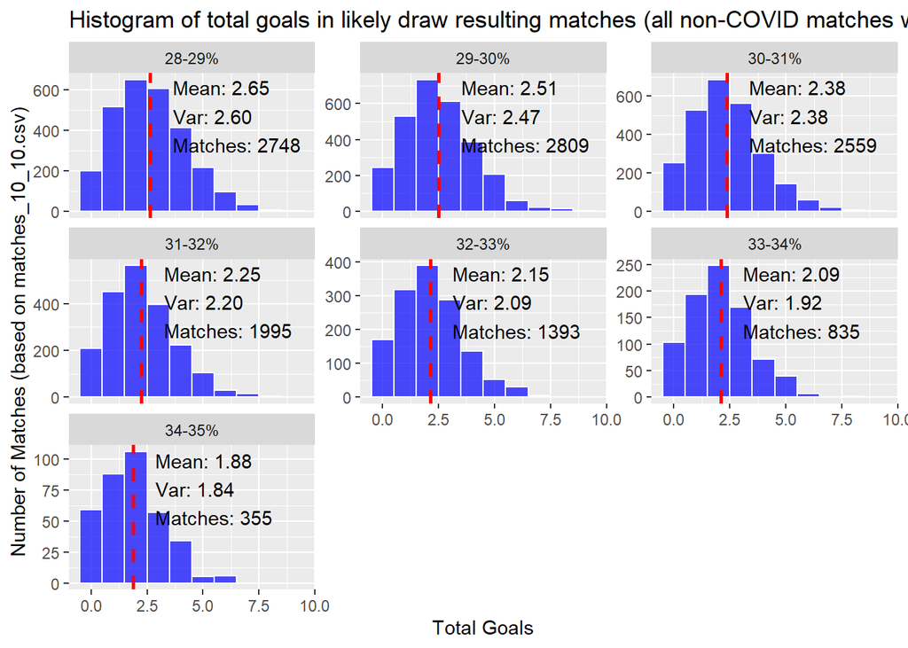

```r
summaries <- draw_matches_tipsport_cut |>
  group_by(bin) |>
  summarize(mean_goals = mean(total_goals, na.rm=T),
            variance = var(total_goals, na.rm=T),
            max_count = max(table(total_goals)),  # the highest bar for positioning
            total_matches = n())  # total number of matches in each bin

chart <- draw_matches_tipsport_cut |> ggplot(aes(x=total_goals)) +
  geom_histogram(binwidth=1, fill="blue", alpha=0.7, color="white") +
  facet_wrap(~bin, scales="free_y") +
  geom_vline(data=summaries, aes(xintercept=mean_goals),
             color="red", linetype="dashed", size=1) +
  geom_text(data=summaries,
            aes(x=mean_goals + 1, y=max_count - 1,
                label=sprintf("Mean: %.2f\nVar: %.2f\nMatches: %d", mean_goals, variance, total_matches)),
            hjust=0, vjust=1) +
  labs(title="Histogram of total goals in likely draw resulting matches (all non-COVID matches with spectators; Tipsport)",
       x="Total Goals", y=paste0("Number of Matches (based on ", src_filename, ")"))
chart
```

```r
filename <- paste0("C:\\Users\\kutalekj\\PycharmProjects\\MyFlashscoreScraper\\src\\total_goals_in_likely_draw_matches\\histograms_tipsport.png")
ggsave(filename, plot = chart, width = 12, height = 10)
```

- **Fortuna**

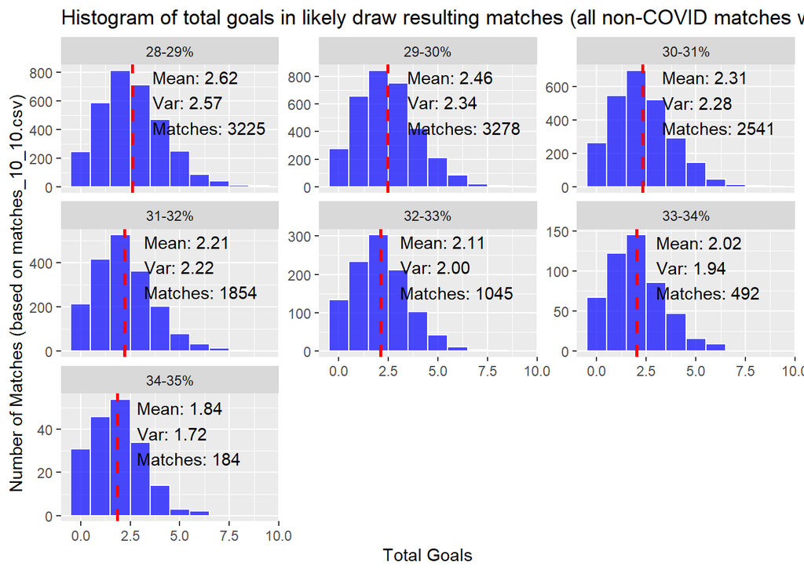

```r
summaries <- draw_matches_fortuna_cut |>
  group_by(bin) |>
  summarize(mean_goals = mean(total_goals, na.rm=T),
            variance = var(total_goals, na.rm=T),
            max_count = max(table(total_goals)),  # the highest bar for positioning
            total_matches = n())  # total number of matches in each bin

chart <- draw_matches_fortuna_cut |> ggplot(aes(x=total_goals)) +
  geom_histogram(binwidth=1, fill="blue", alpha=0.7, color="white") +
  facet_wrap(~bin, scales="free_y") +
  geom_vline(data=summaries, aes(xintercept=mean_goals),
             color="red", linetype="dashed", size=1) +
  geom_text(data=summaries,
            aes(x=mean_goals + 1, y=max_count - 1,
                label=sprintf("Mean: %.2f\nVar: %.2f\nMatches: %d", mean_goals, variance, total_matches)),
            hjust=0, vjust=1) +
  labs(title="Histogram of total goals in likely draw resulting matches (all non-COVID matches with spectators; Fortuna)",
       x="Total Goals", y=paste0("Number of Matches (based on ", src_filename, ")"))

chart
```

```r
filename <- paste0("C:\\Users\\kutalekj\\PycharmProjects\\MyFlashscoreScraper\\src\\total_goals_in_likely_draw_matches\\histograms_fortuna.png")
ggsave(filename, plot = chart, width = 12, height = 10)
```

### Plot number of goals in each match sorted by the draw odds

- **Tipsport**

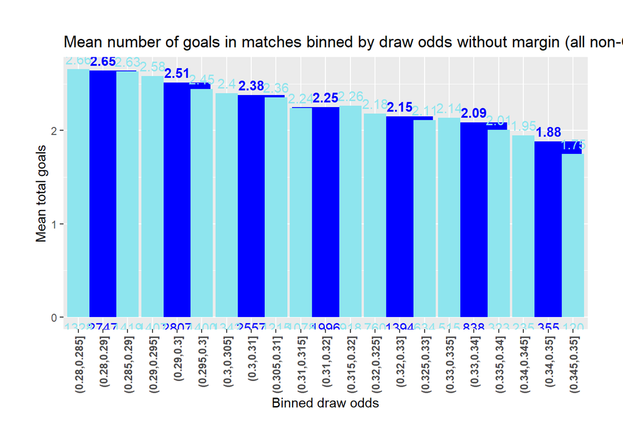

```r
# Sort (asc.)
draw_matches_tipsport_sorted <- draw_matches_tipsport |> arrange("prb_nomarg_0_tips_end")

# Split into 7 bins as before
data_bin_7 <- draw_matches_tipsport_sorted |>
  mutate(draw_odds_bin = cut(prb_nomarg_0_tips_end, breaks = 7)) |>
  group_by(draw_odds_bin) |>
  summarize(average_goals = mean(total_goals, na.rm = TRUE),
            match_count = n(), .groups = 'drop')

# Split into 14 bins
data_bin_14 <- draw_matches_tipsport_sorted |>
  mutate(draw_odds_bin = cut(prb_nomarg_0_tips_end, breaks = 14)) |>
  group_by(draw_odds_bin) |>
  summarize(average_goals = mean(total_goals, na.rm = TRUE),
            match_count = n(), .groups = 'drop')

# Plot
chart <- ggplot() +
  geom_col(data = data_bin_7, aes(x = draw_odds_bin, y = average_goals), fill = "blue", alpha = 1.0) +
  geom_col(data = data_bin_14, aes(x = draw_odds_bin, y = average_goals), fill = "cadetblue2", alpha = 1.0) +
  geom_text(data = data_bin_7, aes(x = draw_odds_bin, y = average_goals, label = round(average_goals, 2)),
            position = position_dodge(width = 0.9), vjust = -0.5, color = "blue", fontface = "bold") + # Odds labels
  geom_text(data = data_bin_14, aes(x = draw_odds_bin, y = average_goals, label = round(average_goals, 2)),
            position = position_dodge(width = 0.9), vjust = -0.5, color = "cadetblue2") + # Odds labels
  geom_text(data = data_bin_7, aes(x = draw_odds_bin, y = 0, label = match_count),
            vjust = 1.5, color = "blue") + # Match count labels
  geom_text(data = data_bin_14, aes(x = draw_odds_bin, y = 0, label = match_count),
            vjust = 1.5, color = "cadetblue2") + # Match count labels
  labs(x = "Binned draw odds", y = "Mean total goals", title = "Mean number of goals in matches binned by draw odds without margin (all non-COVID matches with spectators; Fortuna)") +
  theme(axis.text.x = element_text(angle = 90, vjust = 0.5, hjust=1, face = "bold"),
        plot.margin = unit(c(1, 1, 1, 1), "cm"))

chart
```

```r
# Save
filename <- paste0("C:\\Users\\kutalekj\\PycharmProjects\\MyFlashscoreScraper\\src\\total_goals_in_likely_draw_matches\\bars_by_margins_tipsport.png")
ggsave(filename, plot = chart, width = 12, height = 10)
```

- **Fortuna**

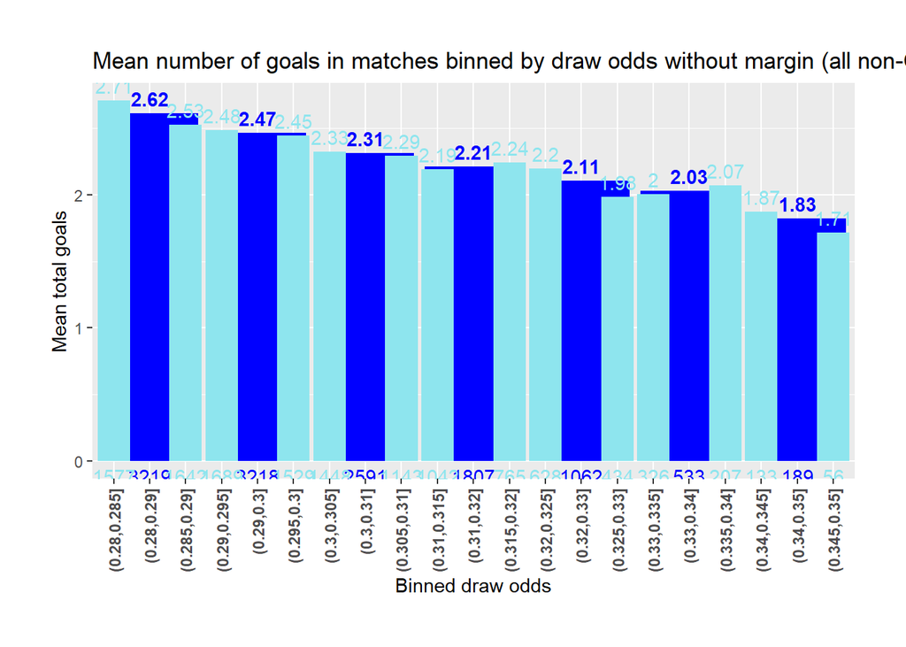

```r
# Sort (asc.)
draw_matches_fortuna_sorted <- draw_matches_fortuna |> arrange("prb_nomarg_0_fort_end")

# Split into 7 bins as before
data_bin_7 <- draw_matches_fortuna_sorted |>
  mutate(draw_odds_bin = cut(prb_nomarg_0_fort_end, breaks = 7)) |>
  group_by(draw_odds_bin) |>
  summarize(average_goals = mean(total_goals, na.rm = TRUE),
            match_count = n(), .groups = 'drop')

# Split into 14 bins
data_bin_14 <- draw_matches_fortuna_sorted |>
  mutate(draw_odds_bin = cut(prb_nomarg_0_fort_end, breaks = 14)) |>
  group_by(draw_odds_bin) |>
  summarize(average_goals = mean(total_goals, na.rm = TRUE),
            match_count = n(), .groups = 'drop')

# Plot
chart <- ggplot() +
  geom_col(data = data_bin_7, aes(x = draw_odds_bin, y = average_goals), fill = "blue", alpha = 1.0) +
  geom_col(data = data_bin_14, aes(x = draw_odds_bin, y = average_goals), fill = "cadetblue2", alpha = 1.0) +
  geom_text(data = data_bin_7, aes(x = draw_odds_bin, y = average_goals, label = round(average_goals, 2)),
            position = position_dodge(width = 0.9), vjust = -0.5, color = "blue", fontface = "bold") + # Odds labels
  geom_text(data = data_bin_14, aes(x = draw_odds_bin, y = average_goals, label = round(average_goals, 2)),
            position = position_dodge(width = 0.9), vjust = -0.5, color = "cadetblue2") + # Odds labels
  geom_text(data = data_bin_7, aes(x = draw_odds_bin, y = 0, label = match_count),
            vjust = 1.5, color = "blue") + # Match count labels
  geom_text(data = data_bin_14, aes(x = draw_odds_bin, y = 0, label = match_count),
            vjust = 1.5, color = "cadetblue2") + # Match count labels
  labs(x = "Binned draw odds", y = "Mean total goals", title = "Mean number of goals in matches binned by draw odds without margin (all non-COVID matches with spectators; Fortuna)") +
  theme(axis.text.x = element_text(angle = 90, vjust = 0.5, hjust=1, face = "bold"),
        plot.margin = unit(c(1, 1, 1, 1), "cm"))

chart
```

```r
# Save
filename <- paste0("C:\\Users\\kutalekj\\PycharmProjects\\MyFlashscoreScraper\\src\\total_goals_in_likely_draw_matches\\bars_by_margins_fortuna.png")
ggsave(filename, plot = chart, width = 12, height = 10)
```

TODO: Auto saving of plots TODO: Violin plots for 7bins (both T&F)